# Informe_Ciclystic

VCRA

2025-02-26

# CYCLISTIC

## Introducción

Cyclistic es un programa de bicicletas compartidas con sede en Chicago, Estados Unidos. El programa ofrece una alternativa de transporte conveniente e inclusiva para residentes y visitantes.

Este ejercicio busca responder a la pregunta de ¿Cómo lograr el éxito de un negocio de bicicletas?. Para ello, se busca responder tres preguntas:

1. ¿En qué se diferencian los socios anuales y los ciclistas ocasionales con respecto al uso de las bicicletas de Cyclistic?
2. ¿Por qué los ciclistas ocasionales comparían membresias anuales de Cyclistic?
3. ¿Cómo puede usar Cyclistic los medios digitales para influenciar a los ciclistas ocasionales a convertirse en miembros?

### Instalación de paquetes y librerias necesarios:

```r
install.packages("tidyverse")
install.packages("lubridate")
```

```r
install.packages("ggplot2")
install.packages("dplyr")
install.packages("rmarkdown")
library("tidyverse")
library("lubridate")
library("ggplot2")
library("dplyr")
library("rmarkdown")
```

### Setear el directorio desde el que se trabajará

```r
getwd()
```

```
## [1] "/cloud/project"
```

```r
setwd("/cloud/project/q")
list.files() ##chequear que se haya cargado correctamente el directorio
```

```
## [1] "q1.csv" "q2.csv" "q3.csv" "q4.csv"
```

```r
list.files(path = "/cloud/project/q", pattern = "*.csv")
```

```
## [1] "q1.csv" "q2.csv" "q3.csv" "q4.csv"
```

### Configurar data frames

```r
q1 <- read_csv("/cloud/project/q/q1.csv")
q2 <- read_csv("/cloud/project/q/q2.csv")
q3 <- read_csv("/cloud/project/q/q3.csv")
q4 <- read_csv("/cloud/project/q/q4.csv")
```

## Manejo de data frames

Se trabaja con cuatro archivos correspondientes a trimestres, los cuales, se combinarán en uno sólo una vez que se haya chequeado el contenido general de los cuatro archivos.

### Comparar columnas y chequear que correspondan entre si

```r
colnames(q1)
```

```
##  [1] "trimestre"          "ride_id"            "rideable_type"
##  [4] "started_at"         "ended_at"           "start_station_name"
##  [7] "end_station_name"   "member_casual"      "ride_length"
## [10] "day_of_week"
```

```r
colnames(q2)
```

```
##  [1] "trimestre"          "ride_id"            "rideable_type"
##  [4] "started_at"         "ended_at"           "start_station_name"
##  [7] "end_station_name"   "member_casual"      "ride_length"
## [10] "day_of_week"
```

```r
colnames(q3)
```

```
##  [1] "trimestre"          "ride_id"            "rideable_type"
##  [4] "started_at"         "ended_at"           "start_station_name"
##  [7] "end_station_name"   "member_casual"      "ride_length"
## [10] "day_of_week"
```

```r
colnames(q4)
```

```
##  [1] "trimestre"          "ride_id"            "rideable_type"
##  [4] "started_at"         "ended_at"           "start_station_name"
##  [7] "end_station_name"   "member_casual"      "ride_length"
## [10] "day_of_week"
```

### Inspeccionar el data frame

```r
str(q1)
```

```
## spc_tbl_ [46,568 × 10] (S3: spec_tbl_df/tbl_df/tbl/data.frame)
##  $ trimestre         : chr [1:46568] "q1_202402" "q1_202401" "q1_202312" "q1_202312" ...
##  $ ride_id           : chr [1:46568] "653B2D8E7F82C175" "6AD51B930230C9AE" "BBCE1828CAE411A6" "455076DE47B284C5" ...
##  $ rideable_type     : chr [1:46568] "classic_bike" "electric_bike" "electric_bike" "classic_bike" ...
##  $ started_at        : chr [1:46568] "03-02-2024 12:50" "04-01-2024 8:16" "21-12-2023 17:49" "20-12-2023 10:00" ...
##  $ ended_at          : chr [1:46568] "03-02-2024 13:08" "04-01-2024 8:21" "21-12-2023 18:08" "20-12-2023 10:09" ...
##  $ start_station_name: chr [1:46568] "DuSable Lake Shore Dr & Monroe St" "Franklin St & Lake St" "Streeter Dr & Grand Ave" "Green St & Washington Blvd" ...
##  $ end_station_name  : chr [1:46568] "Shedd Aquarium" "Stetson Ave & South Water St" "Wilton Ave & Belmont Ave" "Franklin St & Illinois St" ...
##  $ member_casual     : chr [1:46568] "casual" "casual" "member" "member" ...
##  $ ride_length       : chr [1:46568] "00-01-1900 0:17" "00-01-1900 0:05" "00-01-1900 0:18" "00-01-1900 0:09" ...
##  $ day_of_week       : num [1:46568] 7 5 5 4 6 5 6 4 4 4 ...
##  - attr(*, "spec")=
##   .. cols(
##   ..   trimestre = col_character(),
##   ..   ride_id = col_character(),
##   ..   rideable_type = col_character(),
##   ..   started_at = col_character(),
##   ..   ended_at = col_character(),
##   ..   start_station_name = col_character(),
##   ..   end_station_name = col_character(),
##   ..   member_casual = col_character(),
##   ..   ride_length = col_character(),
##   ..   day_of_week = col_double()
##   .. )
##  - attr(*, "problems")=<externalptr>
```

```r
str(q2)
```

```
## spc_tbl_ [102,483 × 10] (S3: spec_tbl_df/tbl_df/tbl/data.frame)
##  $ trimestre         : chr [1:102483] "q2_202405" "q2_202403" "q2_202403" "q2_202403" ...
##  $ ride_id           : chr [1:102483] "7798396522FD252E" "F9D6F51B1773BCD5" "15D13B4CEA2D2B4A" "BBA380DD2EADD10D" ...
##  $ rideable_type     : chr [1:102483] "electric_bike" "classic_bike" "classic_bike" "electric_bike" ...
##  $ started_at        : chr [1:102483] "07-05-2024 6:55" "04-03-2024 11:45" "05-03-2024 18:58" "03-03-2024 10:19" ...
##  $ ended_at          : chr [1:102483] "07-05-2024 7:02" "04-03-2024 11:50" "05-03-2024 19:13" "03-03-2024 10:28" ...
##  $ start_station_name: chr [1:102483] "Lakeview Ave & Fullerton Pkwy" "Elizabeth St & Fulton St" "Franklin St & Adams St (Temp)" "Sheridan Rd & Montrose Ave" ...
##  $ end_station_name  : chr [1:102483] "Wells St & Concord Ln" "Loomis St & Jackson Blvd" "Dearborn Pkwy & Delaware Pl" "Broadway & Barry Ave" ...
##  $ member_casual     : chr [1:102483] "member" "member" "member" "member" ...
##  $ ride_length       : chr [1:102483] "00-01-1900 0:07" "00-01-1900 0:04" "00-01-1900 0:15" "00-01-1900 0:08" ...
##  $ day_of_week       : num [1:102483] 3 2 3 1 5 1 1 4 6 7 ...
##  - attr(*, "spec")=
##   .. cols(
##   ..   trimestre = col_character(),
##   ..   ride_id = col_character(),
##   ..   rideable_type = col_character(),
##   ..   started_at = col_character(),
##   ..   ended_at = col_character(),
##   ..   start_station_name = col_character(),
##   ..   end_station_name = col_character(),
##   ..   member_casual = col_character(),
##   ..   ride_length = col_character(),
##   ..   day_of_week = col_double()
##   .. )
##  - attr(*, "problems")=<externalptr>
```

```r
str(q3)
```

```
## spc_tbl_ [104,857 × 10] (S3: spec_tbl_df/tbl_df/tbl/data.frame)
##  $ trimestre         : chr [1:104857] "q3_202406" "q3_202407" "q3_202407" "q3_202407" ...
##  $ ride_id           : chr [1:104857] "DB109C71FD2190EF" "D8E8CB155131EEAF" "82797053BDD179F3" "C55C35AEE0370967" ...
##  $ rideable_type     : chr [1:104857] "classic_bike" "classic_bike" "classic_bike" "classic_bike" ...
##  $ started_at        : chr [1:104857] "06-06-2024 15:54" "22-07-2024 8:02" "25-07-2024 12:27" "25-07-2024 19:29" ...
##  $ ended_at          : chr [1:104857] "06-06-2024 16:26" "22-07-2024 8:20" "25-07-2024 12:29" "25-07-2024 19:33" ...
##  $ start_station_name: chr [1:104857] "McClurg Ct & Erie St" "Sheridan Rd & Montrose Ave" "Clark St & Wrightwood Ave" "DuSable Lake Shore Dr & Diversey Pkwy" ...
##  $ end_station_name  : chr [1:104857] "Greenview Ave & Diversey Pkwy" "Broadway & Berwyn Ave" "Halsted St & Wrightwood Ave" "Theater on the Lake" ...
##  $ member_casual     : chr [1:104857] "member" "casual" "member" "member" ...
##  $ ride_length       : chr [1:104857] "00-01-1900 0:32" "00-01-1900 0:18" "00-01-1900 0:02" "00-01-1900 0:03" ...
##  $ day_of_week       : num [1:104857] 5 2 5 5 7 7 6 3 4 1 ...
##  - attr(*, "spec")=
##   .. cols(
##   ..   trimestre = col_character(),
##   ..   ride_id = col_character(),
##   ..   rideable_type = col_character(),
##   ..   started_at = col_character(),
##   ..   ended_at = col_character(),
##   ..   start_station_name = col_character(),
##   ..   end_station_name = col_character(),
##   ..   member_casual = col_character(),
##   ..   ride_length = col_character(),
##   ..   day_of_week = col_double()
##   .. )
##  - attr(*, "problems")=<externalptr>
```

```r
str(q4)
```

```
## spc_tbl_ [104,857 × 10] (S3: spec_tbl_df/tbl_df/tbl/data.frame)
##  $ trimestre         : chr [1:104857] "q4_202410" "q4_202409" "q4_202409" "q4_202409" ...
##  $ ride_id           : chr [1:104857] "1AA68B0A785C87C2" "54859147FD14A64C" "CE22C652F64E287B" "51FAF2C8E7BFB6B4" ...
##  $ rideable_type     : chr [1:104857] "electric_bike" "classic_bike" "classic_bike" "classic_bike" ...
##  $ started_at        : chr [1:104857] "29-10-2024 21:46" "02-09-2024 14:30" "06-09-2024 18:35" "17-09-2024 12:31" ...
##  $ ended_at          : chr [1:104857] "29-10-2024 21:52" "02-09-2024 15:11" "06-09-2024 18:44" "17-09-2024 12:35" ...
##  $ start_station_name: chr [1:104857] "Winchester Ave & Elston Ave" "Fort Dearborn Dr & 31st St" "State St & 19th St" "Clark St & Chicago Ave" ...
##  $ end_station_name  : chr [1:104857] "Lincoln Ave & Melrose St" "Fort Dearborn Dr & 31st St" "Wabash Ave & 9th St" "Wells St & Walton St" ...
##  $ member_casual     : chr [1:104857] "member" "casual" "member" "member" ...
##  $ ride_length       : chr [1:104857] "00-01-1900 0:06" "00-01-1900 0:41" "00-01-1900 0:08" "00-01-1900 0:04" ...
##  $ day_of_week       : num [1:104857] 3 2 6 3 2 5 7 2 5 5 ...
##  - attr(*, "spec")=
##   .. cols(
##   ..   trimestre = col_character(),
##   ..   ride_id = col_character(),
##   ..   rideable_type = col_character(),
##   ..   started_at = col_character(),
##   ..   ended_at = col_character(),
##   ..   start_station_name = col_character(),
##   ..   end_station_name = col_character(),
##   ..   member_casual = col_character(),
##   ..   ride_length = col_character(),
##   ..   day_of_week = col_double()
##   .. )
##  - attr(*, "problems")=<externalptr>
```

## Combinar los 4 dataframes en una

```r
all_trips <- bind_rows(q1, q2, q3, q4)
```

# Procesamiento de datos

## Convertir variables temporales

```r
str(all_trips)
```

```
## spc_tbl_ [358,765 × 10] (S3: spec_tbl_df/tbl_df/tbl/data.frame)
##  $ trimestre         : chr [1:358765] "q1_202402" "q1_202401" "q1_202312" "q1_202312" ...
##  $ ride_id           : chr [1:358765] "653B2D8E7F82C175" "6AD51B930230C9AE" "BBCE1828CAE411A6" "455076DE47B284C5" ...
##  $ rideable_type     : chr [1:358765] "classic_bike" "electric_bike" "electric_bike" "classic_bike" ...
##  $ started_at        : chr [1:358765] "03-02-2024 12:50" "04-01-2024 8:16" "21-12-2023 17:49" "20-12-2023 10:00" ...
##  $ ended_at          : chr [1:358765] "03-02-2024 13:08" "04-01-2024 8:21" "21-12-2023 18:08" "20-12-2023 10:09" ...
##  $ start_station_name: chr [1:358765] "DuSable Lake Shore Dr & Monroe St" "Franklin St & Lake St" "Streeter Dr & Grand Ave" "Green St & Washington Blvd" ...
##  $ end_station_name  : chr [1:358765] "Shedd Aquarium" "Stetson Ave & South Water St" "Wilton Ave & Belmont Ave" "Franklin St & Illinois St" ...
##  $ member_casual     : chr [1:358765] "casual" "casual" "member" "member" ...
##  $ ride_length       : chr [1:358765] "00-01-1900 0:17" "00-01-1900 0:05" "00-01-1900 0:18" "00-01-1900 0:09" ...
##  $ day_of_week       : num [1:358765] 7 5 5 4 6 5 6 4 4 4 ...
##  - attr(*, "spec")=
##   .. cols(
##   ..   trimestre = col_character(),
##   ..   ride_id = col_character(),
##   ..   rideable_type = col_character(),
##   ..   started_at = col_character(),
##   ..   ended_at = col_character(),
##   ..   start_station_name = col_character(),
##   ..   end_station_name = col_character(),
##   ..   member_casual = col_character(),
##   ..   ride_length = col_character(),
##   ..   day_of_week = col_double()
##   .. )
##  - attr(*, "problems")=<externalptr>
```

```r
    #started y ended at
all_trips <- all_trips %>%
  mutate(
    started_at = dmy_hm(started_at),  # Convertir a formato fecha-hora
    ended_at = dmy_hm(ended_at)       # Convertir a formato fecha-hora
  )

    #ride length
all_trips <- all_trips %>%
  mutate(
    ride_length = as.numeric(difftime(ended_at, started_at, units = "mins"))
  )
```

### Añadir columnas de dia, mes, año de cada viaje

```r
all_trips$date <- as.Date(all_trips$started_at)
all_trips$month <- format(as.Date(all_trips$date),"%m")
all_trips$day <- format(as.Date(all_trips$date),"%d")
all_trips$year <- format(as.Date(all_trips$date),"%y")
all_trips$day_of_week <- format(as.Date(all_trips$date), "%A")

str(all_trips)
```

```
## tibble [358,765 × 14] (S3: tbl_df/tbl/data.frame)
##  $ trimestre         : chr [1:358765] "q1_202402" "q1_202401" "q1_202312" "q1_202312" ...
##  $ ride_id           : chr [1:358765] "653B2D8E7F82C175" "6AD51B930230C9AE" "BBCE1828CAE411A6" "455076DE47B284C5" ...
##  $ rideable_type     : chr [1:358765] "classic_bike" "electric_bike" "electric_bike" "classic_bike" ...
##  $ started_at        : POSIXct[1:358765], format: "2024-02-03 12:50:00" "2024-01-04 08:16:00" ...
##  $ ended_at          : POSIXct[1:358765], format: "2024-02-03 13:08:00" "2024-01-04 08:21:00" ...
##  $ start_station_name: chr [1:358765] "DuSable Lake Shore Dr & Monroe St" "Franklin St & Lake St" "Streeter Dr & Grand Ave" "Green St & Washington Blvd" ...
##  $ end_station_name  : chr [1:358765] "Shedd Aquarium" "Stetson Ave & South Water St" "Wilton Ave & Belmont Ave" "Franklin St & Illinois St" ...
##  $ member_casual     : chr [1:358765] "casual" "casual" "member" "member" ...
##  $ ride_length       : num [1:358765] 18 5 19 9 8 10 8 6 7 6 ...
##  $ day_of_week       : chr [1:358765] "Saturday" "Thursday" "Thursday" "Wednesday" ...
##  $ date              : Date[1:358765], format: "2024-02-03" "2024-01-04" ...
##  $ month             : chr [1:358765] "02" "01" "12" "12" ...
##  $ day               : chr [1:358765] "03" "04" "21" "20" ...
##  $ year              : chr [1:358765] "24" "24" "23" "23" ...
```

# Análisis descriptivo

```r
summary(all_trips)
```

```
##   trimestre           ride_id          rideable_type
##  Length:358765      Length:358765      Length:358765
##  Class :character   Class :character   Class :character
##  Mode  :character   Mode  :character   Mode  :character
##
##
##
##    started_at                        ended_at
##  Min.   :2023-12-01 00:05:00.00   Min.   :2023-12-01 00:20:00.00
##  1st Qu.:2024-04-22 12:38:00.00   1st Qu.:2024-04-22 12:55:00.00
##  Median :2024-06-19 19:01:00.00   Median :2024-06-19 19:19:00.00
##  Mean   :2024-06-17 22:07:37.26   Mean   :2024-06-17 22:24:12.48
##  3rd Qu.:2024-09-09 13:14:00.00   3rd Qu.:2024-09-09 13:33:00.00
##  Max.   :2024-11-30 22:11:00.00   Max.   :2024-11-30 22:19:00.00
##  start_station_name end_station_name   member_casual       ride_length
##  Length:358765      Length:358765      Length:358765      Min.   :   0.00
##  Class :character   Class :character   Class :character   1st Qu.:   6.00
##  Mode  :character   Mode  :character   Mode  :character   Median :  10.00
##                                                           Mean   :  16.59
##                                                           3rd Qu.:  18.00
##                                                           Max.   :1499.00
##  day_of_week             date               month               day
##  Length:358765      Min.   :2023-12-01   Length:358765      Length:358765
##  Class :character   1st Qu.:2024-04-22   Class :character   Class :character
##  Mode  :character   Median :2024-06-19   Mode  :character   Mode  :character
##                     Mean   :2024-06-17
##                     3rd Qu.:2024-09-09
##                     Max.   :2024-11-30
##      year
##  Length:358765
##  Class :character
##  Mode  :character
##
##
##
```

## Descriptivo de duración de los viajes

```r
mean(all_trips$ride_length)
```

```
## [1] 16.58685
```

```r
median(all_trips$ride_length)
```

```
## [1] 10
```

```r
max(all_trips$ride_length)
```

```
## [1] 1499
```

```r
min(all_trips$ride_length)
```

```
## [1] 0
```

```r
sd(all_trips$ride_length, na.rm = TRUE)  # Desviación estándar
```

```
## [1] 35.53368
```

La duración media de cada viaje corresponde a 16,58 minutos, con una duración máxima por viaje de 1499 minutos. A su vez la desviación estandar corresponde a 35,53 nos indica que existe una alta dispersión de la duración de los viajes.

## Descriptivo de cantidad de viajes por día de semana.

```r
all_trips %>%
  mutate(weekday = wday(started_at, label = TRUE, abbr = FALSE)) %>%
  group_by(weekday) %>%
  summarise(total_rides = n()) %>%
  arrange(weekday)
```

```
## # A tibble: 7 × 2
##   weekday   total_rides
##   <ord>           <int>
## 1 Sunday          47357
## 2 Monday          49402
## 3 Tuesday         49737
## 4 Wednesday       55529
## 5 Thursday        52176
## 6 Friday          50445
## 7 Saturday        54119
```

## Análisis por tipo de usuario (Casual v/s Member)

### Número de viajes por tipo de usuario

```r
all_trips %>%
  count(member_casual)
```

```
## # A tibble: 2 × 2
##   member_casual      n
##   <chr>          <int>
## 1 casual        127015
## 2 member        231750
```

### Duración promedio del viaje por tipo de usuario

```r
all_trips %>%
  group_by(member_casual) %>%
  summarise(
    avg_ride_length = mean(ride_length, na.rm = TRUE),
    median_ride_length = median(ride_length, na.rm = TRUE),
    sd_ride_length = sd(ride_length, na.rm = TRUE)
  )
```

```
## # A tibble: 2 × 4
##   member_casual avg_ride_length median_ride_length sd_ride_length
##   <chr>                   <dbl>              <dbl>          <dbl>
## 1 casual                   24.0                 13           49.9
## 2 member                   12.5                  9           23.3
```

En relación a la duración de los viajes, los usuarios casuales viajan en promedio 24,01 minutos, con una desviación estándar de 49.89 minutos, lo que sugiere que existe mayor variabilidad en los tiempos de viaje a diferencia de los miembros quienes viajaron en promedio 12.51 minutos, con una menor variabilidad en los tiempos de viaje, lo que indica que éstos realizan viajes más uniformes que los usuarios casuales.

### Comparación de tiempos de viaje por tipo de usuario

```r
aggregate(all_trips$ride_length~all_trips$member_casual, FUN=max)
```

```
##   all_trips$member_casual all_trips$ride_length
## 1                  casual                  1499
## 2                  member                  1490
```

```r
aggregate(all_trips$ride_length~all_trips$member_casual, FUN=min)
```

```
##   all_trips$member_casual all_trips$ride_length
## 1                  casual                     0
## 2                  member                     0
```

La duración máxima de viaje de los usuarios casuales alcanza los 1499 minutos, mientras que en los miembros alcanza los 1490 minutos.

### Tiempo promedio de viaje por dia de la semana y tipo de usuario

```r
all_trips %>%
  mutate(weekday = wday(started_at, label = TRUE, abbr = FALSE)) %>%  # Extrae el día de la semana con nombre completo
  group_by(member_casual, weekday) %>%
  summarise(
    number_of_rides = n(),
    average_duration = mean(ride_length, na.rm = TRUE)  # Evita errores con valores NA
  ) %>%
  arrange(member_casual, weekday)
```

```
## # A tibble: 14 × 4
## # Groups:   member_casual [2]
##    member_casual weekday   number_of_rides average_duration
##    <chr>         <ord>               <int>            <dbl>
##  1 casual        Sunday              22365             27.8
##  2 casual        Monday              15175             23.4
##  3 casual        Tuesday             13501             20.5
##  4 casual        Wednesday           16100             20.5
##  5 casual        Thursday            15556             20.9
##  6 casual        Friday              18325             23.0
##  7 casual        Saturday            25993             27.6
##  8 member        Sunday              24992             13.8
##  9 member        Monday              34227             12.0
## 10 member        Tuesday             36236             12.3
## 11 member        Wednesday           39429             12.2
## 12 member        Thursday            36620             11.8
## 13 member        Friday              32120             12.2
## 14 member        Saturday            28126             14.0
```

Los usuarios casuales realizan una menor cantidad de viajes con una duración mayor, siendo los dias de fin de semana los que cuentan con mayor cantidad de viajes, lo cual sugiere que este tipo de usuario realiza mayor cantidad de viajes durante los fines de semana con fines probablemente recreativos y turísticos, mientras que los miembros realizan una mayor cantidad de viajes durante días de semana con una menos duración que los usuarios casuales, lo cual indica que probablemte sean personas que utilizan este medio de transporte para trasladarse hacia sus trabajos.

# Análisis visual

### Número de Viajes por Tipo de Usuario y Día de la Semana

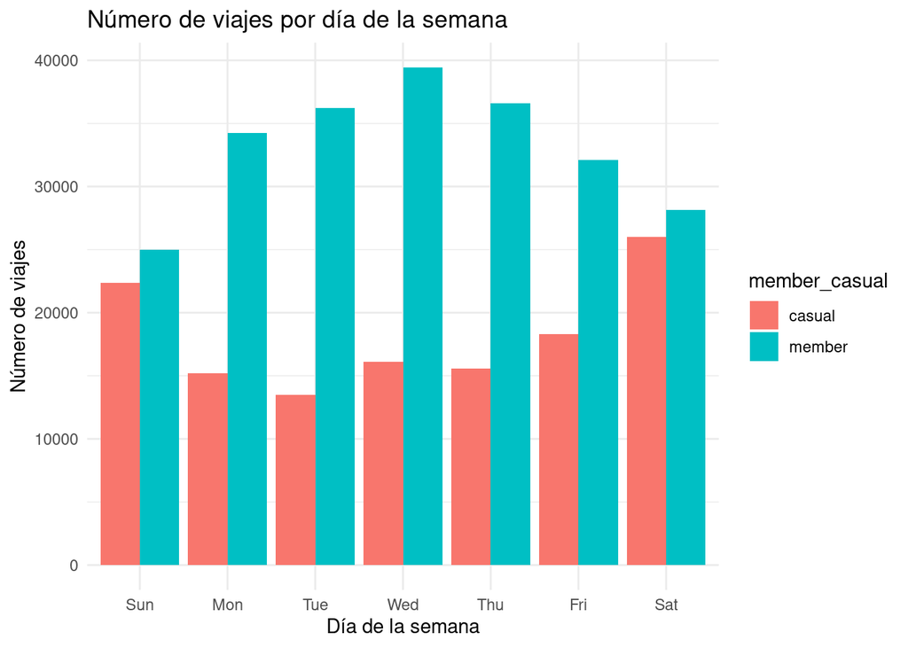

```r
all_trips%>%
  mutate(weekday=wday(started_at, label=TRUE)
  )%>%
  group_by(member_casual, weekday)%>%
  summarise(number_of_rides=n(),
            average_duration=mean(ride_length))%>%
  arrange(member_casual, weekday)%>%
  ggplot(aes(x=weekday, y=number_of_rides, fill=member_casual))+
  geom_col(position="dodge")+  labs(title = "Número de viajes por día de la semana",
                                    x = "Día de la semana",
                                    y = "Número de viajes") +
  theme_minimal()
```

En esta visualización es posible identificar los días de la semana donde los usuarios casuales aumentan la cantidad de viajes, siendo particularmente entre los días viernes y domingo.

### Visualizacion por duracion promedio de viaje por tipo de usuario y dia de la semana.

[figure not shown]

```r
all_trips%>%
  mutate(weekday=wday(started_at, label=TRUE))%>%
  group_by(member_casual, weekday)%>%
  summarise(number_of_rides=n(),
            average_duration=mean(ride_length))%>%
  arrange(member_casual, weekday)%>%
  ggplot(aes(x=weekday, y=average_duration, fill=member_casual))+
  geom_col(position="dodge") + labs(title = "Número de viajes por día de la semana",
                                    x = "Día de la semana",
                                    y = "Número de viajes") +
  theme_minimal()
```

Esta visualización refleja que los tiempos de viaje de los usuarios casuales es siempre mayor a quienes son miembros de Cyclistic, particularmente entre los días de fin de semana.

# Conclusiones

Se evidencia que los usuarios con membresía utilizan las bicicletas de una manera distinta que los que son usuarios casuales, esto debido a que los datos sugieren que los miembros utilizarían estos medios de transporte durante días laborales, con el objetivo de ir y retornar de sus hogares a sus trabajos, a diferencia de los usuarios casuales que utilizan las bicicletas principalmente en fines de semana, para viajes más largos y con objetivos recreacionales principalmente.

Se requieren estrategias de marketing y campañas en medios digitales que atraigan al ciclista ocasional para que compren membresias anuales, con ofertas especiales para favorecer desplazamiento recreativo, por ejemplo, con rutas turísticas en alianzas con productoras de eventos o empresas de turismo local.